# Coursework Report 218192

*N* removed NAs: 3

*N* removed typo: 1

*N* removed <18: 26

*N* total clean: 120

| Group | *N* | *M*<sub>age</sub> | *M*<sub>rating</sub> |
| --- | --- | --- | --- |
| Control | 59 | 20.4 | 6.53 |
| Experim | 61 | 20.4 | 5.11 |

**Main analysis results**

*t*(118) = 10.22, *p* < .001

[interactive chart not shown]

[figure not shown]

[interactive chart not shown]

# Coursework Report 218192

Analysing Data, Spring 2020

# Methods

## Participants

| Condition | *N* | *M*<sub>age</sub> | *SD*<sub>age</sub> |
| --- | --- | --- | --- |
| control | 59 | 20.4 | 1.58 |
| experimental | 61 | 20.4 | 1.56 |

## Design

This study is a replication of the Eliot et al 2010 study “*Red, rank and romance in women viewing men*”, in which they investigate whether colour (specifically red) influences attractiveness. Participants are asked to answer 3 questions about attractiveness, rating a picture with either a red or a white frame, using a Likert scale. Colour is therefore an independent categorical variable with two levels: white for the control group, and red for the experimental group. The Likert scale- ratings, from 1-9, where 1 corresponds to “not attractive at all” and 9 “very attractive” will be used to create a composite score (flat average of the three answers) to estimate *perceived attractiveness*. The operational hypothesis is: Does a different colour frame around an image of a moderately attractive man influence the mean ratings of his perceived attractiveness? The ratings will be summarized into a mean for each group, and we will carry out a t-test in order to determine whether or not differences are significant. Note that the alpha value used in this study is p<0.05.

# Results

In Figure 1, we show the difference in means between both control-white group and experimental-red group. We can observe on the plot that the control group have given a higher mean rating than the experimental group: white-framed pictures (*M* = 6.53), red-framed pictures (*M* = 5.11). The difference in means is 1.42.

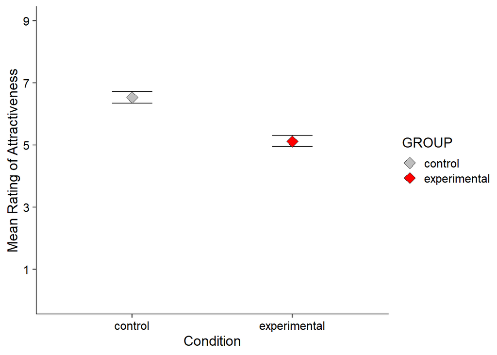

Figure 1. Mean attractiveness rating by condition.

This *t*-test enables us to determine whether the difference is statistically significant. The difference in sample means compared to the SE of differences in means, and therefore allows us to quantify the difference in means and its significance.

```
##
##  Two Sample t-test
##
## data:  comp_score by GROUP
## t = 10, df = 118, p-value <0.0000000000000002
## alternative hypothesis: true difference in means is not equal to 0
## 95 percent confidence interval:
##  1.14 1.69
## sample estimates:
##      mean in group control mean in group experimental
##                       6.53                       5.11
```

This difference in means is significant (*M*<sub>diff</sub> = 1.42, 95% CI [1.14, 1.69], *t* (118) = 10.22, *p* = < .001). The large *t* value (*t* = 10.22) and its significance shown by *p*, suggests that the difference between sample means and error is large enough to suspect that it is unlikely for both samples not to come from the same population. This would suggest that the null hypothesis may not be true.

The significance in difference in means on the evaluated sample suggests that both attractiveness ratings are likely to come from different populations, therefore that colour has an impact on attractiveness ratings. However, our control group has a mean rating higher than that of the experimental group, suggesting that white frame positively impacts perception versus red.

If we assume Elliot’s results correct, we would have expected to find a significant result for colour, and a better score for red.

# Discussion

In their first experiment, Elliot and colleagues concluded that the colour red had a “significant colour effect”. We must also note that this “red effect” was in fact supported by several studies done by Elliot (Elliot & Niesta, 2008; Elliot et al., 2010). As demonstrated by our conducted *t*-test, colour seems to have an impact on attractiveness, which supports our hypothesis with significant evidence. However, unlike what was hypothesized by Elliot et al, the colour red seems not to have a higher rating than the control group. This suggests against their findings. We must firstly address the design of the experiment we replicated, and to what extent our replication differed. The first experiment in Elliot’s study only consisted of 21 undergraduate female participants (Elliot et al., 2010); this small sample is a poor predictor of the general population. In the study, Elliot et al mentioned their aim was to investigate whether colour had an impact on female’s ratings of male attractiveness, but the target population was not further explained or reduced. As a result, the 21-people sample is very unlikely to represent the true population value. Eliot used more participants in the 7 experiments of his study, however, none were large enough, as they never exceeded 55 participants.  
In our replication study, we ended with a sample of 120 participants, which is a better representation of the true population than the study by Elliot. However, it is still small. The experiments conducted by Peperkoorn (Peperkoorn et al., 2016) had a total sample size of 830 men (testing women), and the results did not prove to support Elliot’s *red effect*. Perhaps Elliot et al.’s small samples led them to an unreliable conclusion; our replication study has a small sample size, however, it enabled us to question the conclusions of the original study.

Secondly, some aspects of the design were unclear. Our operational hypothesis mentioned *moderately* attractive men, which is already a biased opinion. No explanation was given about the way that had been decided; further research should use different photos as a means to avoid any bias. We must mention that in other experiments in the same study conducted by Eliot, other photos were used. However, the lack of participants does not allow us to trust the conclusions fully.  
Another limitation in our replication study is the subjective nature of the questionnaires. Factors impacting attractiveness have not been analyzed or determined in the original study, or our replication study. Everyone has different sets of criteria for their romantic interests, and it is unlikely that we would be capable of capturing everything in one ‘perceived attractiveness’ rating. We must comment on the fact that over half of their sample was caucasian: it is unlikely that all culture-based romantic criteria were achieved by this small of a sample size. In addition, the man on the picture was caucasian: perhaps that had a considerable impact on the ratings, and that should be researched further. We must also add that our replication study did not specify the race and sociocultural background of our participants. This limits our study as we assume that every woman has the same criteria for attractiveness. The use of black and white pictures as well as using the same man enabled us to control factors such as redness and facial symmetry; which are possible impactors. (Grammer, K., & Thornhill, R. (1994), cited in Saegusa & Watanabe, 2016). The original study, as well as our replication study used an independent measures test; a repeated measures test would benefit future experiments to try and avoid individual differences in romantic interests. If a repeated measures design is found not to be enough, perhaps narrowing down the ‘target population’ is necessary in the first place. For example, differentiating between cultures, educational levels, social context and professions could be a start to further understanding of this area of research. Perhaps a more general approach could be taken after multiple observations on different groups.

Thirdly, as the white backgrounds have a mean rating higher than that of the red-experimental group, we must analyse the reasons why that must be the case. Two questions rise from these results: is red in fact *unattractive* or is white not suitable as a control colour? Further research in this area could be done to determine what the exact reasons are for colour impacting attractiveness. We replicated the first experiment of the Elliot et al 2010 study, in which white was used as the control colour, because it is “the most unobtrusive” colour. However, later in the paper, experiment 3 interrogates *colour lightness* as a factor in attractiveness. To test this, Elliot et al used another achromatic colour as control, grey, and results showed the experimental red group was rated higher than the control group. (Elliot et al., 2010) Although this is the case, we must take notice of critics that have been made about this paper. Gregory Francis affirms there is publication bias and supports that “the set of studies should be considered nonscientific or anecdotal”, and also states that it seems very unlikely for *all* 7 of the experiments carried out to reject the null hypothesis (Francis, 2013). Elliot wrote an official reply the same year, supporting that the method used by Francis was made for “big meta-analyses” and was therefore not fully relevant to their issue (Elliot & Maier, 2013). These discussions remain nonetheless relevant to our analysis, and points brought up by Elliot are relevant to the area of research. However, it would be preferable to make some further replication studies in order to establish correlation, as Francis’ arguments are strong; and Eliot agreed that some of the replications had stronger designs than he did (Elliot & Maier, 2013). The conclusions brought by Elliot et al in 2010 are not replicated in our study, which supports the need for further research in this area. Hesslinger, Goldbach and Carbon (Hesslinger, V.M. et al., 2015), as well as Peperkoorn, Roberts and Pollet (Peperkoorn et al., 2016) failed to find results that showed as strong of a “red effect” as Elliot et al. showed multiple times in their study.

To conclude, Eliot et al. in their study have shown that colour impacts attractiveness ratings, and our results support this claim. However, our results as well as other replications show that red does not impact attractiveness more than white: is white therefore more attractive? We must mention that the many issues in the design and number of participants as well as critiques of the study shows that more research is necessary. We are unable to make universal claims like Eliot did with his results, as sociocultural aspects have been completely forgotten. Multiple pictures and a repeated measures design should be used in order to avoid bias and ethical issues as well as analysing sociocultural aspects in attractiveness.

# References

Elliot, A. J., & Maier, M. A. (2013). The red-attractiveness effect, applying the Ioannidis and

Trikalinos (2007b) test, and the broader scientific context: A reply to Francis (2013). *Journal of Experimental Psychology: General, 142*(1), 297–300. http://dx.doi.org/10.1037/a0029592

Elliot, A. J., & Niesta, D. (2008). Romantic red: Red enhances men’s attraction to women.

*Journal of Personality and Social Psychology, 95* (5), 1150–1164. https://doi.org/10.1037/0022-3514.95.5.1150

Elliot, A. J., Niesta Kayser, D., Greitemeyer, T., Lichtenfeld, S., Gramzow, R. H., Maier, M. A.,

& Liu, H. (2010). Red, rank, and romance in women viewing men. *Journal of Experimental Psychology: General, 139* (3), 399–417. https://doi.org/10.1037/a0019689

Francis, G. (2013). Publication bias in “Red, rank, and romance in women viewing men,” by

Elliot et al. (2010). *Journal of Experimental Psychology: General, 142* (1), 292–296. http://dx.doi.org/10.1037/a0027923

Hesslinger, V.M., Carbon, C. C., & Goldbach, L. (2015). Men in red: A reexamination of

the red-attractiveness effect | Kopernio.

https://kopernio.com/viewer?doi=10.3758%2Fs13423-015-0866-8&token=WzE2NDU0ODIsIjEwLjM3NTgvczEzNDIzLTAxNS0wODY2LTgiXQ.ELr6udOuysO8Rw8BNADFDel6YGE Peperkoorn, L. S., Roberts, S. C., & Pollet, T. V. (2016). Revisiting the Red Effect on

Attractiveness and Sexual Receptivity: No Effect of the Color Red on Human Mate Preferences. *Evolutionary Psychology, 14* (4), 147470491667384. https://doi.org/10.1177/1474704916673841

Saegusa, C., & Watanabe, K. (2016). Judgments of facial attractiveness as a combination of

facial parts information over time: Social and aesthetic factors. *Journal of Experimental Psychology: Human Perception and Performance, 42* (2), 173–179. http://dx.doi.org/10.1037/xhp0000149